# Manipulating Factors

CMSC 205, Spring 2017

## Example

To learn about factors, let’s work with the candidates data set from mini project 2.

```r
library(tidyverse)
library(forcats)
candidates <- read.csv("https://raw.githubusercontent.com/cmsc205/mini-project-2/master/candidates.csv?token=ABQEtsMxwsxTEJwAxPc5-gQ3vfkYSztUks5ZD2T6wA%3D%3D")
glimpse(candidates)
```

```
## Observations: 5,628
## Variables: 15
## $ cand_id                <fctr> H0AK00089, H0AK00097, H0AL00016, H0AL0...
## $ cand_name              <fctr> CRAWFORD, HARRY T JR, COX, JOHN ROBERT...
## $ cand_party_affiliation <fctr> DEM, REP, UNK, REP, REP, DEM, REP, REP...
## $ cand_election_yr       <int> 2010, 2012, 2010, 2012, 2012, 2008, 201...
## $ cand_office_state      <fctr> AK, AK, AL, AL, AL, AL, AL, AL, AL, AL...
## $ cand_office            <fctr> H, H, H, H, H, H, H, H, H, H, H, H, H,...
## $ cand_office_district   <int> 0, 0, 7, 1, 2, 5, 5, 5, 5, 5, 6, 7, 7, ...
## $ cand_ici               <fctr> C, C, O, C, I, C, C, I, C, C, C, C, I,...
## $ cand_status            <fctr> P, N, C, C, C, C, C, C, C, C, N, C, C,...
## $ cand_pcc               <fctr> C00466698, C00525261, C00464040, C0045...
## $ cand_st1               <fctr> 4350 BUTTE CIR, PO BOX 1092, PO BOX 25...
## $ cand_st2               <fctr> , , , , , , , , SUITE 1311, , , , , , ...
## $ cand_city              <fctr> ANCHORAGE, ANCHOR POINT, BIRMINGHAM, O...
## $ cand_state             <fctr> AK, AK, AL, AL, AL, AL, AL, AL, AL, AL...
## $ cand_zip               <int> 99504, 8388607, 35201, 36561, 36106, 35...
```

## stringsAsFactors

From your initial glimpse at the data set, you should have noticed that `read.csv()` created factor rather than character variables by default. This can be OK, but often it causes many headaches! (Read [stringsAsFactors: An unauthorized biography](http://simplystatistics.org/2015/07/24/stringsasfactors-an-unauthorized-biography/) and/or [stringsAsFactors =](http://notstatschat.tumblr.com/post/124987394001/stringsasfactors-sigh) for more information.)

Some of the drawbacks of this automatic conversion begin to emerge through a simple summary of the data set.

```r
summary(candidates)
```

```
##       cand_id                            cand_name
##  H0AK00089:   1   BOSS, JEFF                  :   3
##  H0AK00097:   1   BRYK, WILLIAM               :   3
##  H0AL00016:   1   KALEMKARIAN, TIMOTHY CHARLES:   3
##  H0AL01030:   1   MICHAELS, DANIEL TRAVIS     :   3
##  H0AL02087:   1   ADAMS, JOHN                 :   2
##  H0AL05049:   1   AKIN, W TODD                :   2
##  (Other)  :5622   (Other)                     :5612
##  cand_party_affiliation cand_election_yr cand_office_state cand_office
##  REP    :2477           Min.   :1986     US     : 608      H:4160
##  DEM    :1879           1st Qu.:2010     CA     : 478      P: 608
##  IND    : 394           Median :2012     TX     : 378      S: 860
##  LIB    : 239           Mean   :2011     FL     : 315
##  OTH    : 152           3rd Qu.:2012     NY     : 242
##  NNE    : 115           Max.   :2020     IL     : 197
##  (Other): 372                            (Other):3410
##  cand_office_district cand_ici cand_status      cand_pcc
##  Min.   : 0.00        C:3968    :   1               : 886
##  1st Qu.: 0.00        I: 540   C:1884      C00254938:   2
##  Median : 3.00        O:1120   F:  58      C00304758:   2
##  Mean   : 7.14                 N:2356      C00316448:   2
##  3rd Qu.: 9.00                 P:1329      C00325738:   2
##  Max.   :53.00                             C00326801:   2
##                                            (Other)  :4732
##                 cand_st1                           cand_st2
##                     : 114                              :5450
##  1212 S VICTORY BLVD:   7   SUITE 100                  :   3
##  504 VAN NESS AVE   :   5   SUITE 200                  :   3
##  GENERAL DELIVERY   :   5   #104                       :   2
##  PO BOX 365         :   5   #202                       :   2
##  PO BOX 15275       :   4   123 E. SAN CARLOS ST., #531:   2
##  (Other)            :5488   (Other)                    : 166
##        cand_city      cand_state      cand_zip
##  CHICAGO    :  56   CA     : 542   Min.   :      0
##  LAS VEGAS  :  51   TX     : 416   1st Qu.:  27874
##  LOS ANGELES:  50   FL     : 365   Median :  52273
##  WASHINGTON :  49   NY     : 264   Mean   : 687457
##  HOUSTON    :  46   IL     : 213   3rd Qu.:  85255
##  NEW YORK   :  39   OH     : 199   Max.   :8388607
##  (Other)    :5337   (Other):3629
```

## Creating factors

A few variables were automatically coded as numbers, but should be factors, such as `cand_office_district` and `cand_zip`. These are easily converted to factors

```r
candidates <- candidates %>%
  mutate(cand_office_district = as.factor(cand_office_district),
                     cand_zip = as.factor(cand_zip))
```

Let’s take a look at the summaries of our new factor to ensure that things worked

```r
candidates %>%
  count(cand_office_district)
```

```
## # A tibble: 54 × 2
##    cand_office_district     n
##                  <fctr> <int>
## 1                     0  1605
## 2                     1   423
## 3                     2   467
## 4                     3   366
## 5                     4   321
## 6                     5   258
## 7                     6   238
## 8                     7   223
## 9                     8   201
## 10                    9   160
## # ... with 44 more rows
```

```r
candidates %>%
  count(cand_zip) %>%
  arrange(desc(n))
```

```
## # A tibble: 3,912 × 2
##    cand_zip     n
##      <fctr> <int>
## 1   8388607   430
## 2         0   140
## 3     91502     8
## 4     20515     7
## 5     60010     7
## 6     96813     7
## 7     96950     7
## 8     25314     6
## 9     84604     6
## 10    90017     6
## # ... with 3,902 more rows
```

Why do we have a `0` in district? Why do we have two impossible zip codes (`0` and `8388607`)?

The data dictionary tells us that `0` is the district used for “at large” congressional candidates as well as candidates for Senate and Presidential candidates.

A quick filter statement doesn’t reveal what’s going on with the zip. More research is needed!

```r
wierd_zip <- candidates %>%
  filter(cand_zip == "8388607")
head(wierd_zip)
```

```
##     cand_id               cand_name cand_party_affiliation
## 1 H0AK00097        COX, JOHN ROBERT                    REP
## 2 H0AR03030 WHITAKER, DAVID JEFFREY                    DEM
## 3 H0AR03055           WOMACK, STEVE                    REP
## 4 H0AZ01184         FLAKE, JEFF MR.                    REP
## 5 H0AZ03321          PARKER, VERNON                    REP
## 6 H0AZ03354 MORRIS, PAULINA VASQUEZ                    REP
##   cand_election_yr cand_office_state cand_office cand_office_district
## 1             2012                AK           H                    0
## 2             2010                AR           H                    3
## 3             2012                AR           H                    3
## 4             2012                AZ           H                    6
## 5             2012                AZ           H                    9
## 6             2010                AZ           H                    3
##   cand_ici cand_status  cand_pcc                   cand_st1 cand_st2
## 1        C           N C00525261                PO BOX 1092
## 2        O           P C00468033                 PO BOX 957
## 3        I           C C00477745 134 N PLEASANT RIDGE DRIVE
## 4        I           C C00347260     4222 E MCLELLAN CIRCLE  UNIT 19
## 5        C           C C00541508      5635 E  LINCOLN DRIVE     # 18
## 6        O           P C00475806                PO BOX 2036
##         cand_city cand_state cand_zip
## 1    ANCHOR POINT         AK  8388607
## 2    FAYETTEVILLE         AR  8388607
## 3          ROGERS         AR  8388607
## 4            MESA         AZ  8388607
## 5 PARADISE VALLEY         AZ  8388607
## 6         PHOENIX         AZ  8388607
```

## Recoding a factor

Sometimes, the factor labels in the original data set are not quite what we want for our plots, etc. `fct_recode()` allows us to specify new labels for levels.

For example, consider the `cand_ici` (Incumbent Challenger Status)

```r
candidates %>%
  count(cand_ici)
```

```
## # A tibble: 3 × 2
##   cand_ici     n
##     <fctr> <int>
## 1        C  3968
## 2        I   540
## 3        O  1120
```

One letter labels here are not informative enough, so we need to expand them. The data dictionary reveals that

- C = Challenger
- I = Incumbent
- O = Open Seat is used to indicate an open seat. Open seats are defined as seats where the incumbent never sought re-election.

It’s easy to recode this variable using `mutate` and `fct_recode`:

```r
candidates <- candidates %>%
  mutate(cand_ici = fct_recode(cand_ici,
                               "Challenger" = "C",
                               "Incumbent" = "I",
                               "Open seat" = "O"
  ))

candidates %>%
  count(cand_ici)
```

```
## # A tibble: 3 × 2
##     cand_ici     n
##       <fctr> <int>
## 1 Challenger  3968
## 2  Incumbent   540
## 3  Open seat  1120
```

A nice feature of `fct_recode` is that you do not need to specify all of the levels, just the levels you wish to recode. For example, some candidates do not have complete mailing address, so we might want to introduce `missing` labels:

```r
candidates <- candidates %>%
  mutate(cand_state = fct_recode(cand_state, "missing" = ""))
```

## Reordering a factor

Suppose we wish to create a bar chart of `cand_ici` (Incumbent Challenger Status)

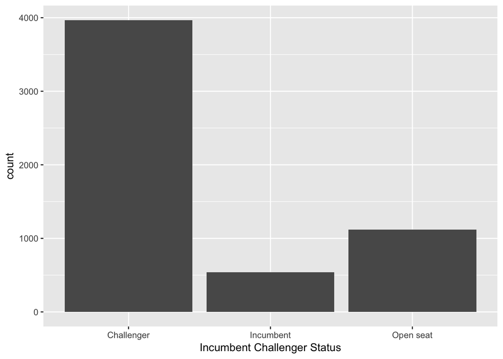

```r
ggplot(candidates, aes(x = cand_ici)) +
  geom_bar() +
  labs(x = "Incumbent Challenger Status")
```

How can we reorder the bars? We have used the `reorder` function before, but there are easier functions to use in the `forcats` package.

For example, to reorder the bar chart, we simply use the `fct_infreq()` function.

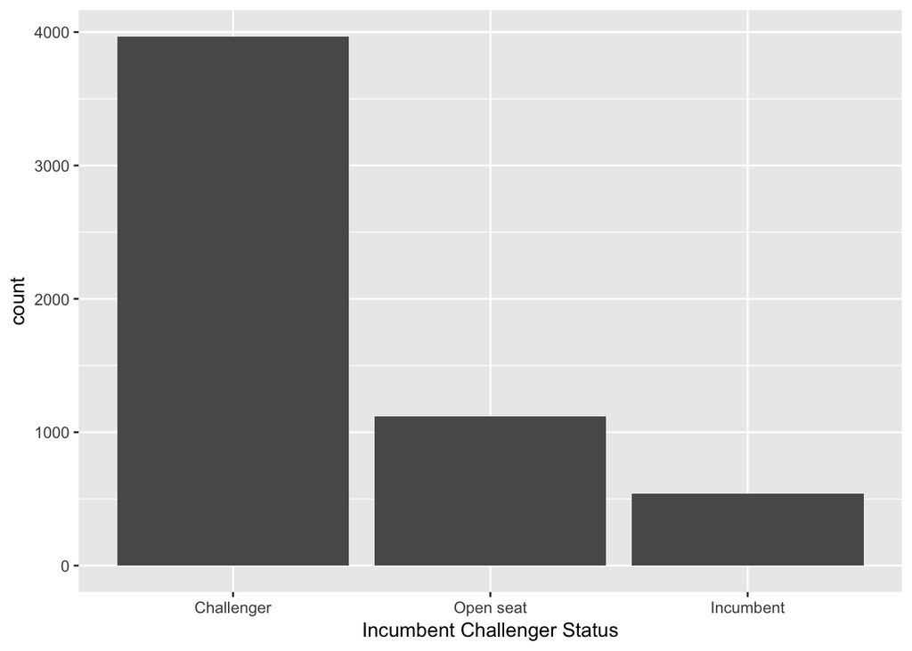

```r
ggplot(candidates, aes(x = fct_infreq(cand_ici))) +
  geom_bar() +
  labs(x = "Incumbent Challenger Status")
```

If we want to reverse the order, then we can add the `fct_rev()` function to the call.

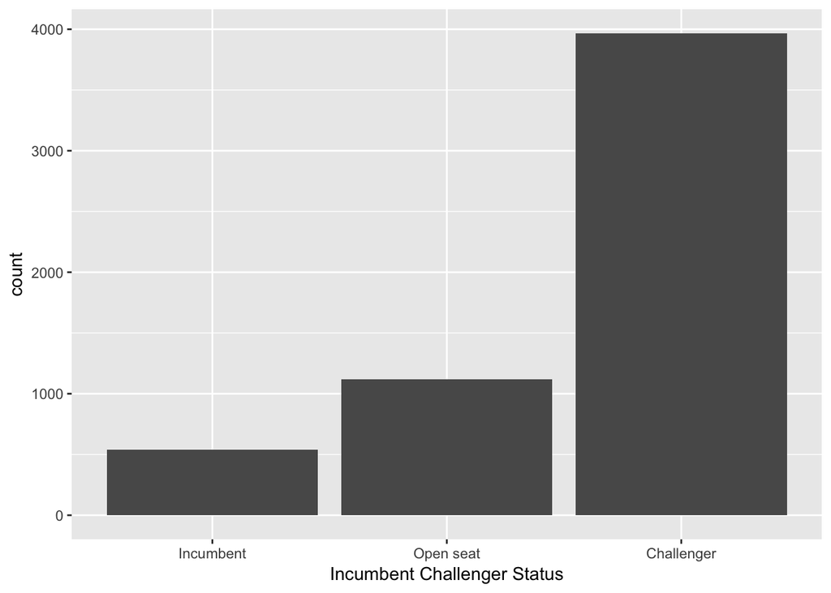

```r
ggplot(candidates, aes(x = fct_infreq(cand_ici) %>% fct_rev())) +
  geom_bar() +
  labs(x = "Incumbent Challenger Status")
```

Alternatively, we may only need to pull one factor level to the “front”, in order to do this, we use `fct_relevel()`:

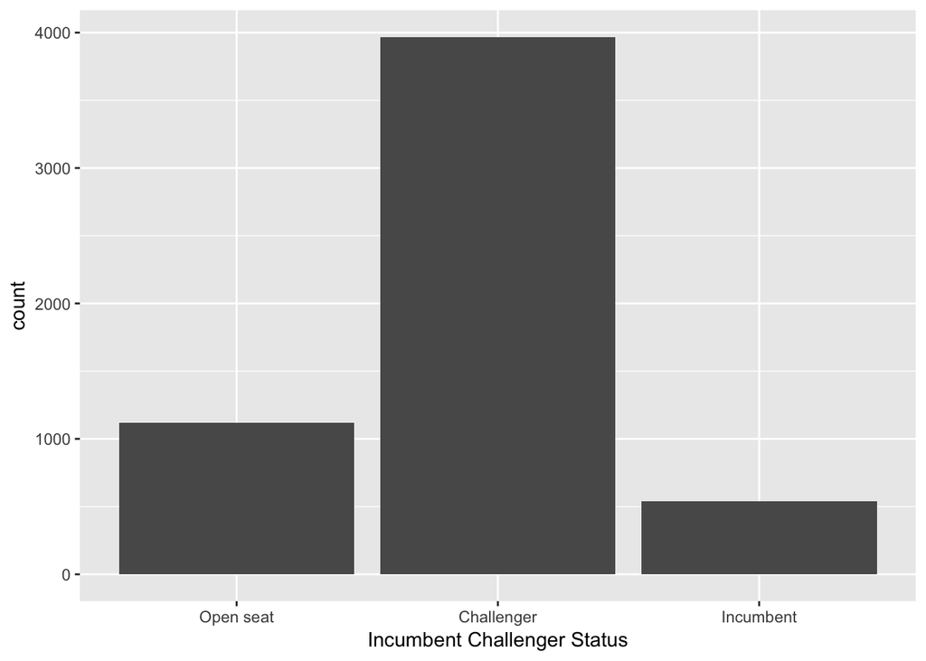

```r
ggplot(candidates, aes(x = fct_relevel(cand_ici, "Open seat"))) +
  geom_bar() +
  labs(x = "Incumbent Challenger Status")
```

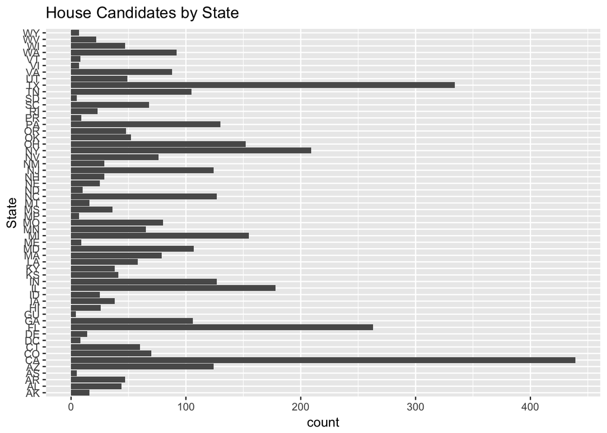

```r
house_cand <- candidates %>%
  filter(cand_office == "H") %>%
  count(cand_office_state)

## The original plot
house_cand %>%
  ggplot(aes(x = cand_office_state, y = n)) +
  geom_bar(stat = "identity") +
  coord_flip() +
  labs(x = "State",  y = "count", title = "House Candidates by State")
```

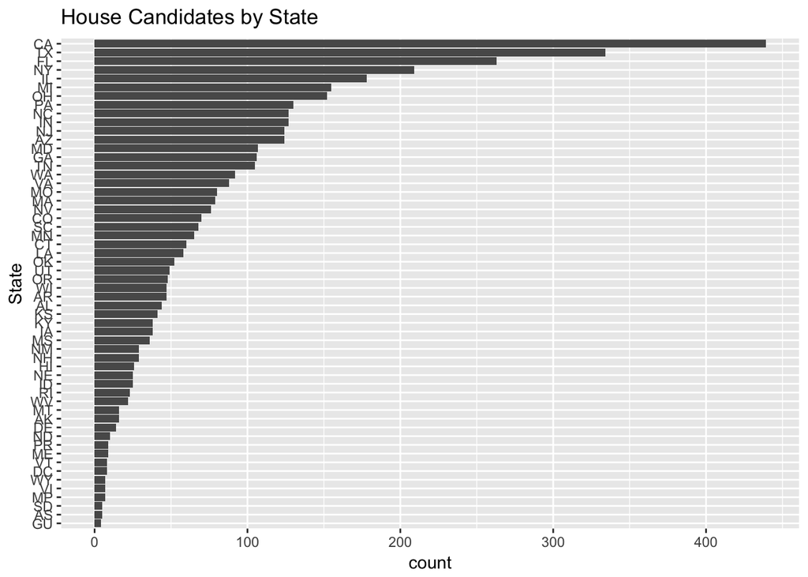

```r
## The ordered plot
house_cand %>%
  ggplot(aes(x = reorder(cand_office_state, n), y = n)) +
  geom_bar(stat = "identity") +
  coord_flip() +
  labs(x = "State", y = "count", title = "House Candidates by State")
```

## Collapsing factor levels

We can use `fct_collapse` to combine levels of factors, such as combining house and senate candidates to form a “Congressional” label.

```r
candidates <- candidates %>%
  mutate(cand_type = fct_collapse(cand_office,
                                  presidential = "P",
                                  congressional = c("H", "S")
  ))

candidates %>%
  count(cand_type)
```

```
## # A tibble: 2 × 2
##       cand_type     n
##          <fctr> <int>
## 1 congressional  5020
## 2  presidential   608
```

## Lumping small factors together

Taking a look at the `cand_party_affiliation` variable reveals 38 unique political parties!

```r
candidates %>%
  count(cand_party_affiliation) %>%
  arrange(desc(n))
```

```
## # A tibble: 38 × 2
##    cand_party_affiliation     n
##                    <fctr> <int>
## 1                     REP  2477
## 2                     DEM  1879
## 3                     IND   394
## 4                     LIB   239
## 5                     OTH   152
## 6                     NNE   115
## 7                     GRE   112
## 8                     UNK   105
## 9                     DFL    22
## 10                    CON    20
## # ... with 28 more rows
```

Using `fct_lump` we can lump together many small factor levels.

```r
candidates <- candidates %>%
  mutate(cand_party_affiliation = fct_lump(cand_party_affiliation, n = 4))

candidates %>%
  count(cand_party_affiliation)
```

```
## # A tibble: 5 × 2
##   cand_party_affiliation     n
##                   <fctr> <int>
## 1                    DEM  1879
## 2                    IND   394
## 3                    LIB   239
## 4                    REP  2477
## 5                  Other   639
```